# Predicting Disrupted Flights using Machine Learning

## Importing Data

```python
# Basic data handling and array manipulation
import numpy as np
import pandas as pd

# Visualization libraries
import matplotlib.pyplot as plt
import seaborn as sns

# Model evaluation and selection tools
from sklearn.model_selection import train_test_split, StratifiedKFold, cross_val_predict, GridSearchCV
from sklearn.metrics import (roc_curve, auc, roc_auc_score, f1_score, confusion_matrix,
                             precision_recall_curve, precision_score, recall_score,
                             accuracy_score, make_scorer, mutual_info_score, PrecisionRecallDisplay)

# Machine learning models
from sklearn.linear_model import LogisticRegression, SGDClassifier
from sklearn.ensemble import RandomForestClassifier
from sklearn.tree import DecisionTreeClassifier
from sklearn.calibration import CalibratedClassifierCV

# Preprocessing, encoders, and pipeline utilities
from sklearn.preprocessing import OneHotEncoder, StandardScaler
from sklearn.impute import SimpleImputer
from sklearn.compose import ColumnTransformer
from sklearn.pipeline import Pipeline
import category_encoders as ce
from category_encoders.target_encoder import TargetEncoder
from sklearn.base import BaseEstimator, TransformerMixin
from sklearn.utils.validation import check_is_fitted

# Statsmodels for advanced statistical modeling
import statsmodels.api as sm
from scipy.stats import spearmanr

# Suppress warnings from sklearn (optional)
import warnings
from sklearn.exceptions import ConvergenceWarning
warnings.filterwarnings(action='ignore', category=ConvergenceWarning)

# For Reproducibility
import random
random.seed(42)
np.random.seed(42)

# Configuration options for pandas and plotting
pd.options.mode.chained_assignment = None
pd.set_option('display.max_columns', None)
```

Importing the the trainining and the testing data seperatly for clarity. When importing the data since there was an error in the formating of the CSV files meaning that an extra columns of data was created for the two features relating to state names, a work-around was implemented by importing the data without the feature names attached, then removing the excess columns (i.e columns indices 26,35) and then afterwards reapplying the orginal column head titles.

Additionally, NA values for the columns '*Disruption*' were removed. The NA values for '*Disruption*' were removed as it was the column which we were trying to predict and thus it would have been mis-representitive if we imputted data for the truth column.

```python
filepaths = [
    '/cs/datasets/ID5059/Coursework1/3_large/Combined_Flights_large_train_2018.csv',
    '/cs/datasets/ID5059/Coursework1/3_large/Combined_Flights_large_train_2019.csv',
    '/cs/datasets/ID5059/Coursework1/3_large/Combined_Flights_large_train_2020.csv',
    '/cs/datasets/ID5059/Coursework1/3_large/Combined_Flights_large_train_2021.csv',
    '/cs/datasets/ID5059/Coursework1/3_large/Combined_Flights_large_train_2022.csv'
]

# Specify the column indices to drop
columns_to_drop_indices = [26, 35]

# Storing Column Names
first_file = filepaths[0]
df_names = pd.read_csv(first_file, nrows=0)
column_names = df_names.columns.tolist()

# Initialize an empty list to store DataFrames
dfs = []

# Iterate through each file path in the list
for filepath in filepaths:

    # Read the CSV file into a DataFrame, skipping the first row
    df = pd.read_csv(filepath, skiprows=1, header=None)

    # Convert indices to column names for columns to drop
    columns_to_drop = df.columns[columns_to_drop_indices]

    # Drop the specified columns and reassign to df
    df = df.drop(columns=columns_to_drop, axis=1)

    # Append the processed DataFrame to the list
    dfs.append(df)

    # Concatenate all DataFrames in the list into one DataFrame
    combined_df = pd.concat(dfs, ignore_index=True)

# Assigning Column Names
combined_df.columns = column_names

# Dropping na rows since Disruption is truth column so should not be imputed
combined_df = combined_df.dropna(subset=['Disruption'])
```

```python
filepaths = [
    '/cs/datasets/ID5059/Coursework1/3_large/Combined_Flights_large_test_2018.csv',
    '/cs/datasets/ID5059/Coursework1/3_large/Combined_Flights_large_test_2019.csv',
    '/cs/datasets/ID5059/Coursework1/3_large/Combined_Flights_large_test_2020.csv',
    '/cs/datasets/ID5059/Coursework1/3_large/Combined_Flights_large_test_2021.csv',
    '/cs/datasets/ID5059/Coursework1/3_large/Combined_Flights_large_test_2022.csv'
]

# Initialize an empty list to store DataFrames
dfs_test = []

# Iterate through each file path in the list
for filepath in filepaths:
    # Read the CSV file into a DataFrame, skipping the first row
    df = pd.read_csv(filepath, skiprows=1, header=None)

    # Convert indices to column names for columns to drop
    columns_to_drop = df.columns[columns_to_drop_indices]

    # Drop the specified columns and reassign to df
    df = df.drop(columns=columns_to_drop, axis=1)

    # Append the processed DataFrame to the list
    dfs_test.append(df)

    # Concatenate all DataFrames in the list into one DataFrame
    combined_df_test = pd.concat(dfs_test, ignore_index=True)


# Assigning Column Names
combined_df_test.columns = column_names

# Dropping na rows since Disruption is truth column so should not be imputed
combined_df_test = combined_df_test.dropna(subset=['Disruption'])
```

### Splitting data into test and valadation set

The test data was split into an 80/20 split so that 20% of the data could be used as a validation set. Ideally we would have preffered to use **K-fold cross validation** instead but due to computational limitations this was not possible and hence the choice of using a valdation set was selected instead.

```python
# Split the data into training and testing sets with an 80/20 split
train_data, val_data = train_test_split(combined_df, test_size=0.2, random_state=42)

# Making a copy of the training data for exploratory data analysis
df = train_data.copy()
```

## Exploratory Data Analysis

```python
# Clear the maximum number of columns to be displayed, so that all will be visible.
pd.set_option('display.max_columns', None)

# Starting by showing basic information about the df

# Printing first few rows and identiying how many features the dataset contains
print(display(df))

# The types these features are
print(df.dtypes)

# How many NA values are present
print(df.isna().sum(axis=0))
```

|  | FlightDate | Airline | Origin | Dest | CRSDepTime | CRSElapsedTime | Distance | Year | Quarter | Month | DayofMonth | DayOfWeek | Marketing_Airline_Network | Operated_or_Branded_Code_Share_Partners | DOT_ID_Marketing_Airline | IATA_Code_Marketing_Airline | Flight_Number_Marketing_Airline | Operating_Airline | DOT_ID_Operating_Airline | IATA_Code_Operating_Airline | Tail_Number | Flight_Number_Operating_Airline | OriginAirportID | OriginAirportSeqID | OriginCityMarketID | OriginCityName | OriginState | OriginStateFips | OriginStateName | … |
| --- | --- | --- | --- | --- | --- | --- | --- | --- | --- | --- | --- | --- | --- | --- | --- | --- | --- | --- | --- | --- | --- | --- | --- | --- | --- | --- | --- | --- | --- | --- |
| 1137491 | 2020-01-25 | Southwest Airlines Co. | MCO | MEM | 1700 | 130.0 | 684 | 2020 | 1 | 1 | 25 | 6 | WN | WN | 19393 | WN | 1282 | WN | 19393 | WN | N8579Z | 1282 | 13204 | 1320402 | 31454 | Orlando | FL | 12 | Florida | … |
| 808694 | 2019-01-13 | United Air Lines Inc. | DEN | BDL | 1800 | 214.0 | 1671 | 2019 | 1 | 1 | 13 | 7 | UA | UA | 19977 | UA | 1887 | UA | 19977 | UA | N66848 | 1887 | 11292 | 1129202 | 30325 | Denver | CO | 8 | Colorado | … |
| 1870812 | 2021-06-12 | American Airlines Inc. | BOS | DFW | 1605 | 259.0 | 1562 | 2021 | 2 | 6 | 12 | 6 | AA | AA | 19805 | AA | 1163 | AA | 19805 | AA | N179UW | 1163 | 10721 | 1072102 | 30721 | Boston | MA | 25 | Massachusetts | … |
| 1430561 | 2020-03-10 | Mesa Airlines Inc. | IAH | LGA | 1205 | 224.0 | 1416 | 2020 | 1 | 3 | 10 | 2 | UA | UA_CODESHARE | 19977 | UA | 6081 | YV | 20378 | YV | N85358 | 6081 | 12266 | 1226603 | 31453 | Houston | TX | 48 | Texas | … |
| 2119881 | 2022-05-20 | Southwest Airlines Co. | MEM | MDW | 1735 | 90.0 | 480 | 2022 | 2 | 5 | 20 | 5 | WN | WN | 19393 | WN | 1074 | WN | 19393 | WN | N8604K | 1074 | 13244 | 1324402 | 33244 | Memphis | TN | 47 | Tennessee | … |
| ... | ... | ... | ... | ... | ... | ... | ... | ... | ... | ... | ... | ... | ... | ... | ... | ... | ... | ... | ... | ... | ... | ... | ... | ... | ... | ... | ... | ... | ... | … |
| 732226 | 2019-02-20 | American Airlines Inc. | CLT | DTW | 1712 | 107.0 | 500 | 2019 | 1 | 2 | 20 | 3 | AA | AA | 19805 | AA | 831 | AA | 19805 | AA | N721UW | 831 | 11057 | 1105703 | 31057 | Charlotte | NC | 37 | North Carolina | … |
| 110283 | 2018-04-20 | Endeavor Air Inc. | ATL | SGF | 1640 | 116.0 | 563 | 2018 | 2 | 4 | 20 | 5 | DL | DL_CODESHARE | 19790 | DL | 3481 | 9E | 20363 | 9E | N348PQ | 3481 | 10397 | 1039707 | 30397 | Atlanta | GA | 13 | Georgia | … |
| 1692789 | 2021-08-19 | American Airlines Inc. | MIA | CLE | 2115 | 181.0 | 1080 | 2021 | 3 | 8 | 19 | 4 | AA | AA | 19805 | AA | 2440 | AA | 19805 | AA | N835AW | 2440 | 13303 | 1330303 | 32467 | Miami | FL | 12 | Florida | … |
| 2229130 | 2022-07-16 | Southwest Airlines Co. | PHX | HOU | 2110 | 150.0 | 1020 | 2022 | 3 | 7 | 16 | 6 | WN | WN | 19393 | WN | 4112 | WN | 19393 | WN | N216WR | 4112 | 14107 | 1410702 | 30466 | Phoenix | AZ | 4 | Arizona | … |
| 2219156 | 2022-03-26 | Spirit Air Lines | CLE | MCO | 1735 | 150.0 | 895 | 2022 | 1 | 3 | 26 | 6 | NK | NK | 20416 | NK | 708 | NK | 20416 | NK | N601NK | 708 | 11042 | 1104205 | 30647 | Cleveland | OH | 39 | Ohio | … |

1868363 rows × 43 columns

```
None
FlightDate                                  object
Airline                                     object
Origin                                      object
Dest                                        object
CRSDepTime                                   int64
CRSElapsedTime                             float64
Distance                                     int64
Year                                         int64
Quarter                                      int64
Month                                        int64
DayofMonth                                   int64
DayOfWeek                                    int64
Marketing_Airline_Network                   object
Operated_or_Branded_Code_Share_Partners     object
DOT_ID_Marketing_Airline                     int64
IATA_Code_Marketing_Airline                 object
Flight_Number_Marketing_Airline              int64
Operating_Airline                           object
DOT_ID_Operating_Airline                     int64
IATA_Code_Operating_Airline                 object
Tail_Number                                 object
Flight_Number_Operating_Airline              int64
OriginAirportID                              int64
OriginAirportSeqID                           int64
OriginCityMarketID                           int64
OriginCityName                              object
OriginState                                 object
OriginStateFips                              int64
OriginStateName                             object
OriginWac                                    int64
DestAirportID                                int64
DestAirportSeqID                             int64
DestCityMarketID                             int64
DestCityName                                object
DestState                                   object
DestStateFips                                int64
DestStateName                               object
DestWac                                      int64
DepTimeBlk                                  object
```

[output cut: 34 more lines]

```
OriginWac                                      0
DestAirportID                                  0
DestAirportSeqID                               0
DestCityMarketID                               0
DestCityName                                   0
DestState                                      0
DestStateFips                                  0
DestStateName                                  0
DestWac                                        0
DepTimeBlk                                     0
CRSArrTime                                     0
ArrTimeBlk                                     0
DistanceGroup                                  0
Disruption                                     0
dtype: int64
```

The output above highlights an issue that many of the attributes are stored as type '*int64*' when they are infact categorical, the impact of this is seen when the histograms are plotted below as many of the features such as '*year*' have been interpreted as a continuous variables when in fact they should be considered categorical since there are only 5 of them present in our data. This results in a historgram only showing values at the values which the categories represent (spikes at relevent categories).

Another observation can be made from the final output of the number of NA values for each column that after having dropped the NA values for '*Disruption*' ,with the reason mentioned before,the only column that contains missing values is the *Tail_Number* and *CRSElapsedTime*. This is very useful for the data exploration section as it means we have an almost complete dataset without having to do any imputation of data. Since *Tail_Number* was not considered a useful feature to include in the model its values were not imputed and it was discarded.

Now that we can see which features have been included in the dataset we can begin by identifying which features might be of interest and further analysis, these features and their justifications have been listed below.

- *FlightDate* : The date a flight departs could have an impact on wether it is going to be delayed as some days may a higher rate of disruption due to an increased overal rate of travel (e.g public holidays / summer season) another reason why it may be influencal is due to environmental issues, for example there may be a higher rate of disruption during certain time periods like during winter as the weather could affect how many flights are able to depart on time.
- *Airline*: The disruption rate may vary by airline since each airline operates as independent companies and hence may have independent disruptions rate. This could be for example that some airlines could have a higher rate of disruption due as they are operating a much larger volume of shorter flight and delays are more likely to occour with several back to back short flights compred to a single long haul flight.
- *Origin*: The airport from which a plane departs could have an impact on if it is delayed since each aiport would have varying levels of traffic and so possibly airports that have higher levels of traffic may have a higher rate of disruption.
- *Dest*: Similarly to *Origin* destination airports that have a higher level of traffic may also cause a higher rate of disruption since if an airport is extremely busy, aircrafts are usually given a very specific time slot for when they can land, if this small window is missed then sometimes planes are forced to wait for a next available slot, this waiting time could therefore cause delays.
- '*CRSDepTime*','*CRSArrTime*': Represents the Computer Reservation System Departure Time, this is essentially when the flight is meant to depart from its origin airport. This is not when the flight actually departs but instead an indication of when it is scheduled to, this could have an impact since flight travelling during parts of the day may have a different rate of disruption. An example could be that airlines that operate short haul flights, usually have many sucessive flights one after another, this would mean that if a delay were to occour on an earlier flight this could have a knock on impact on flights later on in the day.
- '*CRSElapsedTime*': The predicted flight time gives an indication of how long the flight is meant to take, and hence how far it is predicted to travel, the connection to disruption as mentioned before is that shorter flights may be prone to a higher rate of disruption due to the fact that they usually occour back to back one after another so flights which are going further occour less often and possibly are less disrupted.
- '*Distance*': This feature links to discussions about *CRSElapsedTime* and investigations will be done below to see if there is a interaction between these two features
- '*Year*','*Quarter*','*Month*','*DayofMonth*','*DayOfWeek*': These catagorical features have also been investigated with the same reasoning as before that certain categories may have different rate of disruption.

Additionally to all of the features described above some others were also included in the exploration stage just for completness and to give better insight in case any features gave useful information to the model.

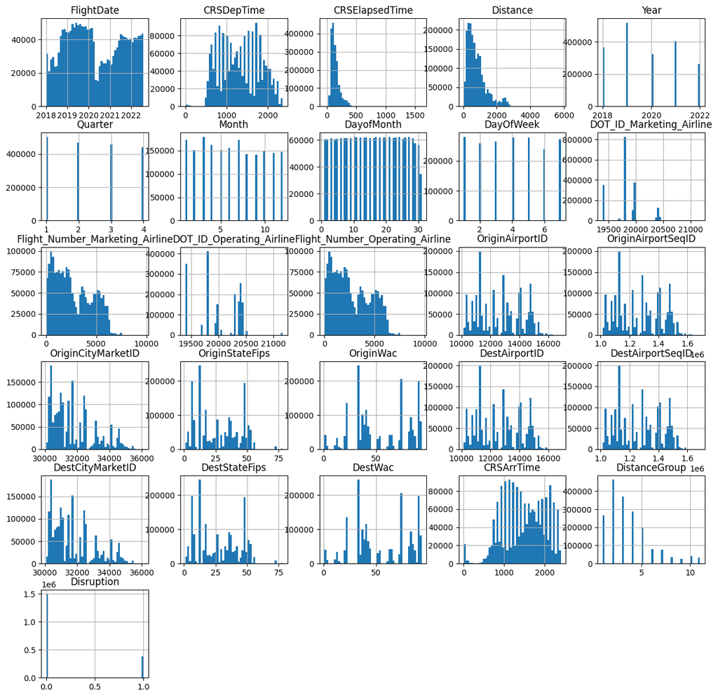

```python
df['FlightDate'] = pd.to_datetime(df['FlightDate'])
df = df.dropna(subset=['Disruption'])

# Plotting historgrams for features
df.hist(bins = 50 ,figsize=(15,15))
plt.show()
```

Insights from the histograms above:

- As suspected the histogram has interpreted some of the categorical columns as numeric and hence has spikes where the categories are, this does give an insight into the frequency of flights for each catagory for example that Saturday (day 6) seems to have less flights than other days.
- There appears to be an imbalence in the frequency of flights throughout the years and this is investigated further below
- The scales of the numeric attributes vary such as time from 0-2400 to distance which goes from 0-6000. This will mean that in the pre-processing stage a standardiser will need to be implemented to correct for this.
- Some histograms are tail heavy (both right and left skewed), this could could cause issues for the Machine learning models as it may be harder for them to detect patterns, this will be correct again by standerdising the data to produce more "bell-shaped" distributions.

The next step of the exploration will be to plot some of the more interesting fetures in more depth. The figure below shows some of thes selected categorical features, they have been plotted to show to show the proportion of them which have disrupted flights vs not disrupted. This has been done so that if there is a trend of the proportion of flights from a certain category then this will be seen more clearly as the bars will deviate more from the same height. This was done as there was an imbalence in the frequency of many categories so when the frequency was plotted instead it made it harder to determine where imbalences of proportions were, which is the more imformative metric. This being said this did have the impact that were the frequency of a category was very low the proportion metric became very volatile since each entry for this category had a much larger weighting, this will be seen below.

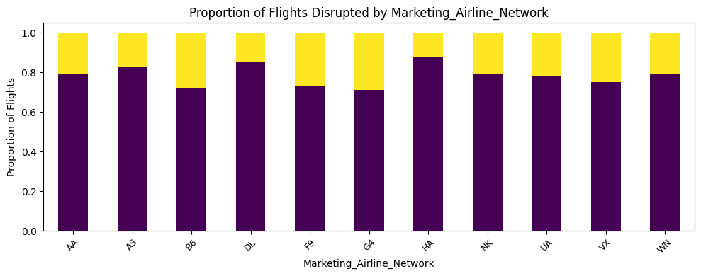

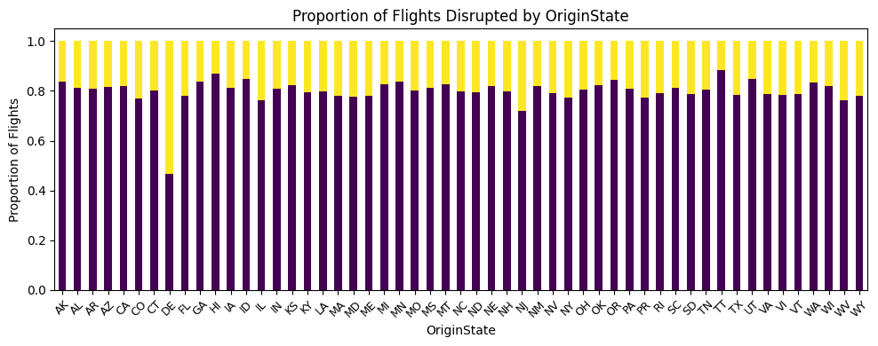

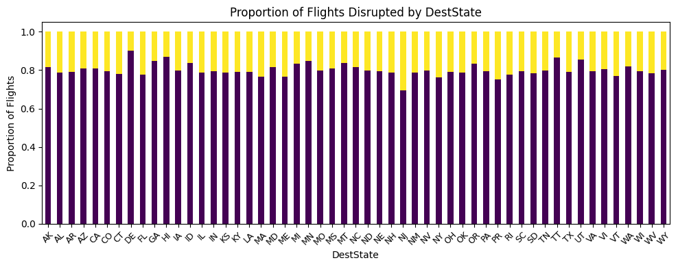

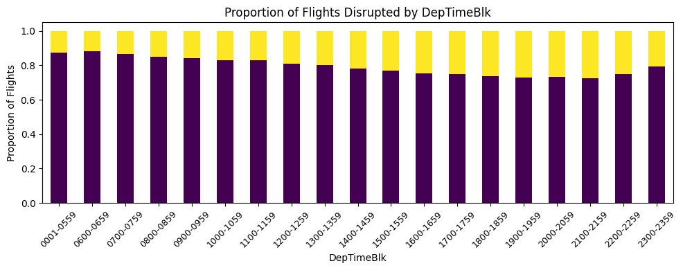

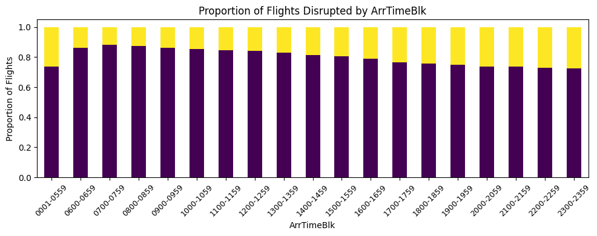

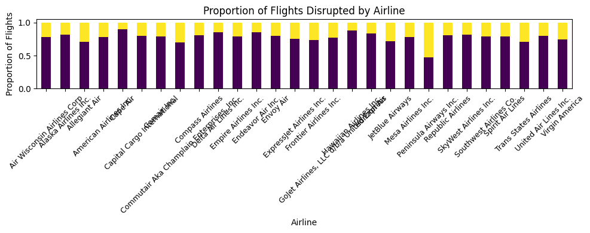

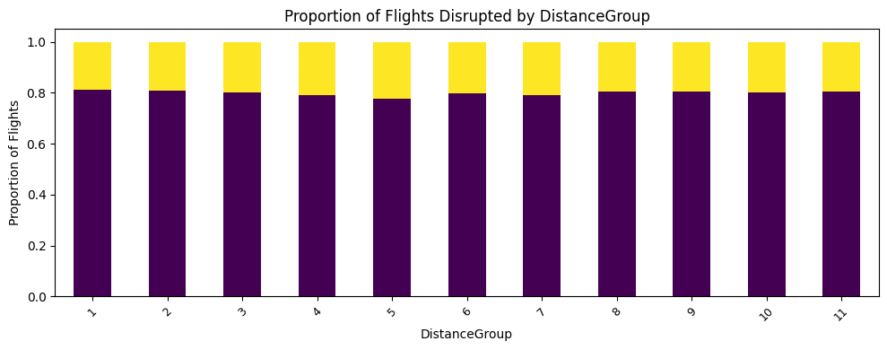

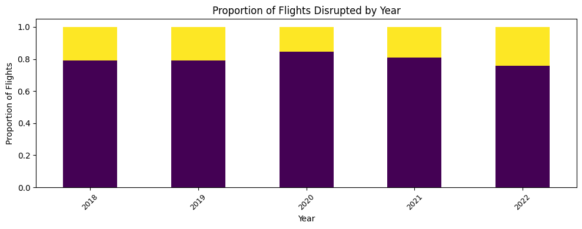

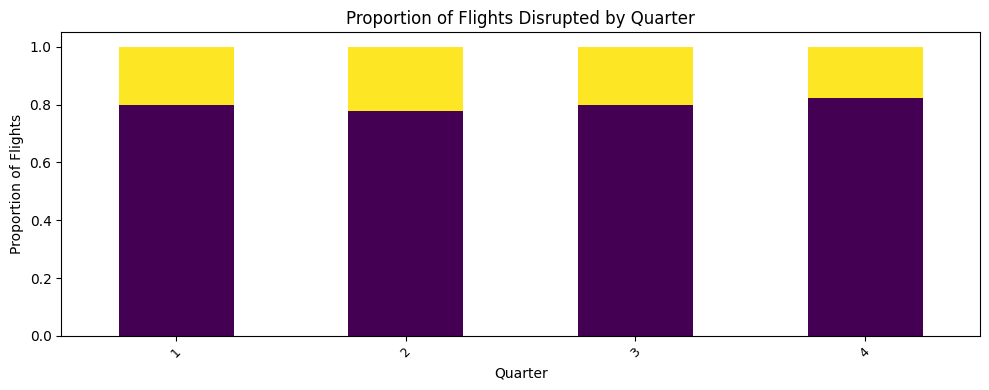

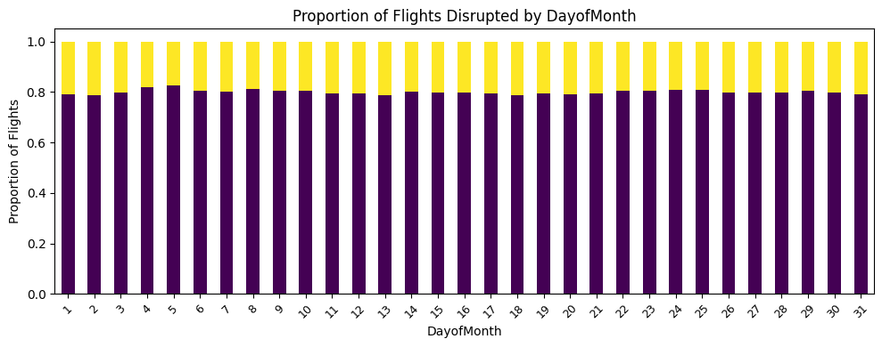

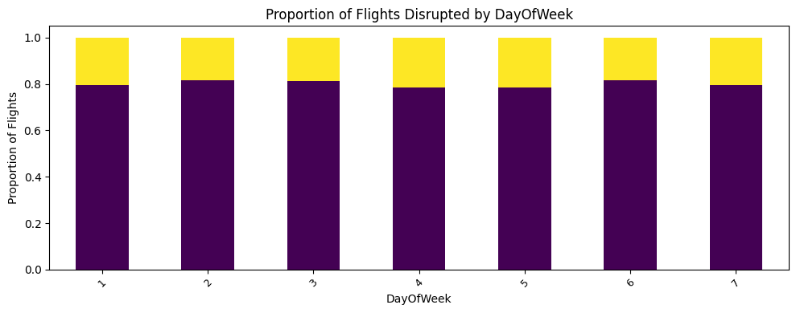

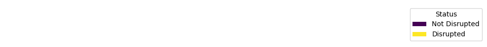

```python
# List of columns to create bar charts for
columns_to_plot = ['Marketing_Airline_Network', 'OriginState', 'DestState', 'DepTimeBlk', 'ArrTimeBlk', 'Airline', 'DistanceGroup', 'Year', 'Quarter', 'DayofMonth','DayOfWeek']

# Adjust the figure size for a more condensed plot and set the legend to display only once
figsize = (10, 4)  # Adjust figure size to make plots more condensed

for column in columns_to_plot:
    # Calculate the count of disrupted vs. not disrupted flights for each category in the column
    disrupted_counts = df.groupby([column, 'Disruption']).size().unstack(fill_value=0)

    # Calculate the proportion of disrupted flights for each category
    disrupted_proportions = disrupted_counts.div(disrupted_counts.sum(axis=1), axis=0)

    # Plot the proportions
    ax = disrupted_proportions.plot(kind='bar', stacked=True, figsize=figsize, colormap='viridis', legend=False)
    plt.title(f'Proportion of Flights Disrupted by {column}')
    plt.xlabel(column)
    plt.ylabel('Proportion of Flights')
    plt.xticks(rotation=45, fontsize=9)
    plt.tight_layout()
    plt.show()

# Show the legend separately
handles, labels = ax.get_legend_handles_labels()
plt.figure(figsize=(10, 1))  # An arbitrary figure size to fit the legend
plt.legend(handles, ['Not Disrupted', 'Disrupted'], title='Status', bbox_to_anchor=(1.05, 1), loc='upper left')
plt.axis('off')  # Hide axes

plt.show()
```

Discussion about the plots above:

- 'Airline','*OriginState*' and '*DestState*': all of these features seemed to have some imbalence in their categories meaning that they could be useful columns to include. A note here is that for the '*OriginState*' graph there is a dip for the *DE* state this is because as mentioned above there were very few flights coming this state meaning its disribution was ill-representive. This should not be reason for consern however as when the information is passed into the model it will only account for a very few number of entries and hence will not cause any major impact for other predictions.
- '*Year*','*Quarter*','*DayofMonth*','*DayOfWeek*': All seemed to have relatively balanced catategories of proportions of flights being disrupted and hence would not be very useful when trying to predict for new data.
- '*DepTimeBlk*','*ArrTimeBlk*': Both displayed a very interesting smooth trend of proportion of flights being cancelled and so very much seemed to have a influence in disruption. The only reason they were not included in the model is because using the other numeric columns '*CRSDepTime*','*CRSArrTime*' give essentially the same information as these categorical features, this is shown in the figures below where the continuous numerical columns were discretised into bins and again showed the trends seen in these categorical features.

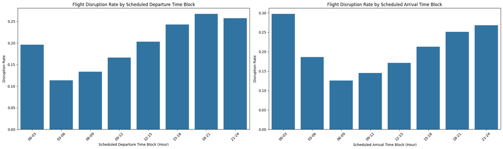

```python
df['CRSDepHour'] = df['CRSDepTime'] // 100
df['CRSDepHourBlock'] = pd.cut(df['CRSDepHour'], bins=[0, 3, 6, 9, 12, 15, 18, 21, 24],
                               labels=['00-03', '03-06', '06-09', '09-12', '12-15', '15-18', '18-21', '21-24'],
                               right=False)
disruption_rate_departure = df.groupby('CRSDepHourBlock', observed=True)['Disruption'].mean().reset_index()

df['CRSArrHour'] = df['CRSArrTime'] // 100
df['CRSArrHourBlock'] = pd.cut(df['CRSArrHour'], bins=[0, 3, 6, 9, 12, 15, 18, 21, 24],
                               labels=['00-03', '03-06', '06-09', '09-12', '12-15', '15-18', '18-21', '21-24'],
                               right=False)
disruption_rate_arrival = df.groupby('CRSArrHourBlock', observed=True)['Disruption'].mean().reset_index()

# Setup for the side-by-side plots
fig, ax = plt.subplots(1, 2, figsize=(20, 6))

# Plot for Departure Time Block Disruption Rate
sns.barplot(x='CRSDepHourBlock', y='Disruption', data=disruption_rate_departure, ax=ax[0])
ax[0].set_title('Flight Disruption Rate by Scheduled Departure Time Block')
ax[0].set_xlabel('Scheduled Departure Time Block (Hour)')
ax[0].set_ylabel('Disruption Rate')
ax[0].tick_params(axis='x', rotation=45)

# Plot for Arrival Time Block Disruption Rate
sns.barplot(x='CRSArrHourBlock', y='Disruption', data=disruption_rate_arrival, ax=ax[1])
ax[1].set_title('Flight Disruption Rate by Scheduled Arrival Time Block')
ax[1].set_xlabel('Scheduled Arrival Time Block (Hour)')
ax[1].set_ylabel('Disruption Rate')
ax[1].tick_params(axis='x', rotation=45)

plt.tight_layout()
plt.show()
```

As suspected, once we discretised the numeric features a similar trend of the rate of disruption has appeared and from this we should hence include either the numeric or the categorical features. Seeing as though the numeric information shows greater fidelity it was chosen to be added to the model.

The next step is to investigate the numeric columns and see which provide useful insight, the below shows the correlation coefficient being found for all numeric columns against the disruption column. Keeping in mind some of these numeric columns are actually categorical in nature.

The thing to note with the analysis is that it would only detect linear relationships between the target varible so further analysis must be done to detect non-linear relationships too.

```python
# Select only numeric columns for correlation calculation
numeric_df = df.select_dtypes(include=['number'])

# Calculate the correlation matrix for numeric columns only
corr_matrix = numeric_df.corr()

print(corr_matrix["Disruption"].sort_values(ascending=False))
# Trying to detect linear relationships between features and Disruption
# Disruption/ArrDel15/Diverted cannot be included as they are found after the flight lands
# Dep/Arr Time show promising correlations so are included
```

```
Disruption                         1.000000
CRSDepTime                         0.123167
CRSDepHour                         0.122936
CRSArrTime                         0.103704
CRSArrHour                         0.103640
DOT_ID_Marketing_Airline           0.031795
DOT_ID_Operating_Airline           0.017163
CRSElapsedTime                     0.014125
DistanceGroup                      0.012623
Distance                           0.012507
DestStateFips                      0.008884
OriginStateFips                    0.006834
Year                               0.006620
DayOfWeek                          0.005990
DayofMonth                         0.003065
DestAirportID                      0.000625
DestAirportSeqID                   0.000625
DestCityMarketID                  -0.000331
Flight_Number_Operating_Airline   -0.000907
Flight_Number_Marketing_Airline   -0.000907
OriginAirportID                   -0.011330
OriginAirportSeqID                -0.011330
OriginCityMarketID                -0.016892
OriginWac                         -0.017741
DestWac                           -0.017789
Month                             -0.026444
Quarter                           -0.026452
Name: Disruption, dtype: float64
```

From the above we can see that '*CRSDepTime*','*CRSArrTime*' seem to have a correlation to the disruption and so they were all included in the model. More analysis of other features sich as '*CRSElapsedTime*' will be done to see if it is worth being put into the model. With these features we have conducted a Spearman which is a non-parametric test (does not rely on assumptions about distribution of data) to identify if there is a monotonic relationship (linear/non-linear) between the features and '*Disruption*'.

```python
# Droping small number of NA value CRSElapsedTime so that Spearman's test works
df = df.dropna(subset=['CRSElapsedTime'])
numeric_columns = ['CRSDepTime','CRSArrTime','CRSElapsedTime','Distance']

# Iterate over numeric columns
for col in numeric_columns:
    # Skip the 'Disruption' column itself
    if col == 'Disruption':
        continue

    # Perform Spearman's rank correlation test
    corr, p_value = spearmanr(df[col], df['Disruption'])

    # Print the results
    print(f"{col}: Spearman's correlation coefficient = {corr:.3f}, P-value = {p_value:.3f}")
```

```
CRSDepTime: Spearman's correlation coefficient = 0.125, P-value = 0.000
CRSArrTime: Spearman's correlation coefficient = 0.114, P-value = 0.000
CRSElapsedTime: Spearman's correlation coefficient = 0.021, P-value = 0.000
Distance: Spearman's correlation coefficient = 0.020, P-value = 0.000
```

From the results of this test we can see that all the features appear as significant and hence a montonic relationship is present. However not that '*CRSElapsedTime*' and '*Distance*' seem to have a weak correlation but we still included in the model since they were still considered significant by the test.

The next step is to investigate the trend that we determined of the variation of the frequency of flight during the years the data was recorded. This has been done by grouping the data by the number of disrupted flights by month across the entire span of time provided too see if there is a trend present.

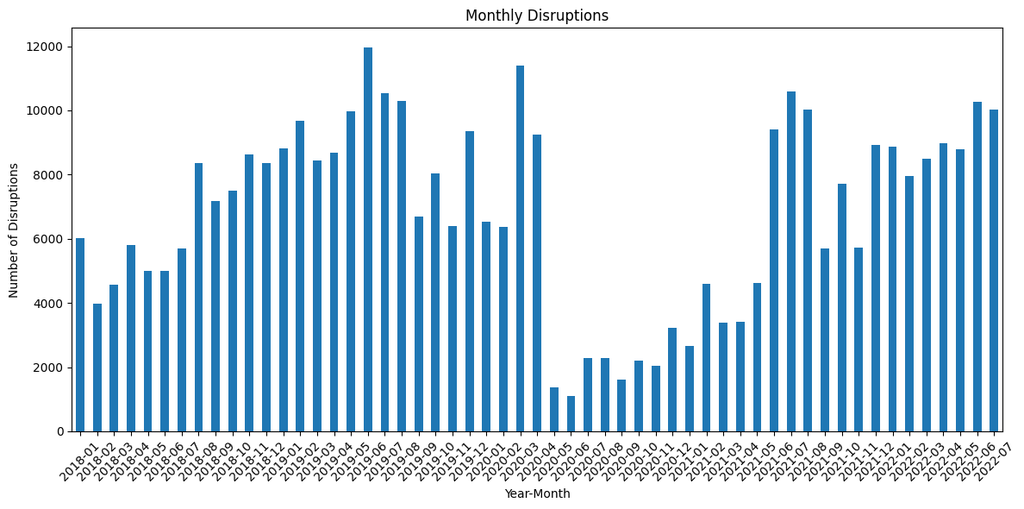

```python
# Splitting Flight Date up by month to show how frequency of flights vary
df['FlightDate'] = pd.to_datetime(df['FlightDate'])
df['YearMonth'] = df['FlightDate'].dt.to_period('M')
monthly_disruptions = df[df['Disruption'] == True].groupby('YearMonth').size()

plt.figure(figsize=(12, 6))
monthly_disruptions.plot(kind='bar')
plt.title('Monthly Disruptions')
plt.xlabel('Year-Month')
plt.ylabel('Number of Disruptions')
plt.xticks(rotation=45)  # Rotate the x-axis labels for better readability
plt.tight_layout()  # Adjust layout to make room for the rotated x-axis labels
plt.show()
```

From the graph above we can see there is a signifcant drop in the frequency in flights between April of 2020 and April of 2021. Of course we are aware of external factors, such as Covid 19 pandemic had a huge impact on the airline industry and this is the trend we are witnessing here. To counteract this we will feature engineer a new column as a binary indicator as to if a flight occoured between this period of not, this will hopefully help the model account for this dip in the frequency of data during this period.

The next step is to analyse the trend between '*CRSElapsedTime*' and '*Disruption*' in greater depth and see if it is worth including it in the model. This has been done below by creating a graph showing one the frequency of flights in discretised bins for this feature as well as the proportion of these flights that were disrupted.

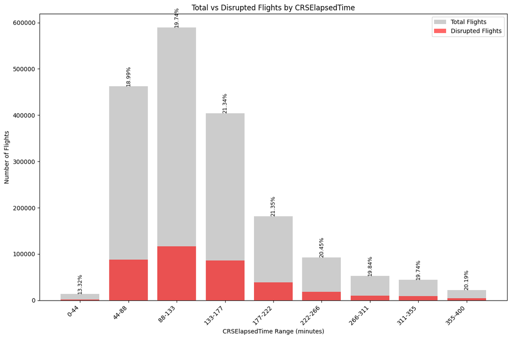

```python
# Filter the dataset to exclude negative CRSElapsedTime values and consider only up to 500 minutes
df_filtered = df[(df['CRSElapsedTime'] >= 0) & (df['CRSElapsedTime'] <= 400)]

# Define new bins for 'CRSElapsedTime' focusing up to 500 minutes
bins = np.linspace(0, 400, 10)  # Reduced number of bins and limit up to 500 minutes
df_filtered['ElapsedTimeBin'] = pd.cut(df_filtered['CRSElapsedTime'], bins=bins)

# Calculate counts and proportions for each bin
total_counts = df_filtered.groupby('ElapsedTimeBin', observed=True).size()
disrupted_counts = df_filtered[df_filtered['Disruption'] == 1].groupby('ElapsedTimeBin', observed=True).size()

# Ensure all bins are included in the disrupted_counts by reindexing with the bins from total_counts
disrupted_counts_reindexed = disrupted_counts.reindex(total_counts.index, fill_value=0)

# Calculate the proportion of disrupted flights for annotations
proportion_disrupted_for_annotation = disrupted_counts_reindexed / total_counts

# Plotting the bars for total flights and disrupted flights
plt.figure(figsize=(12, 8))
bars = plt.bar(range(len(total_counts)), total_counts, label='Total Flights', color='grey', alpha=0.4)

# Annotate each bar with the proportion disrupted
for bar, proportion in zip(bars, proportion_disrupted_for_annotation):
    yval = bar.get_height()
    plt.text(bar.get_x() + bar.get_width()/2, yval, f'{proportion:.2%}', ha='center', va='bottom', fontsize=9, rotation=90)

plt.xticks(range(len(total_counts)), [f'{int(bin.left)}-{int(bin.right)}' for bin in total_counts.index], rotation=45, ha="right")
plt.xlabel('CRSElapsedTime Range (minutes)')
plt.ylabel('Number of Flights')
plt.bar(range(len(disrupted_counts_reindexed)), disrupted_counts_reindexed, label='Disrupted Flights', color='red', alpha=0.6)
plt.title('Total vs Disrupted Flights by CRSElapsedTime')
plt.legend()
plt.tight_layout()
plt.show()
```

From the graph above we can see that there does appear to be a variation in the rates of disruption based on the estimated length of time of the flight, for this reason it was included in the model.

The next plot returns to our discussion about if there is a connection between '*CRSElapsedTime*' and '*Distance*', since one might suspect that flights that take longer are likely to go further.

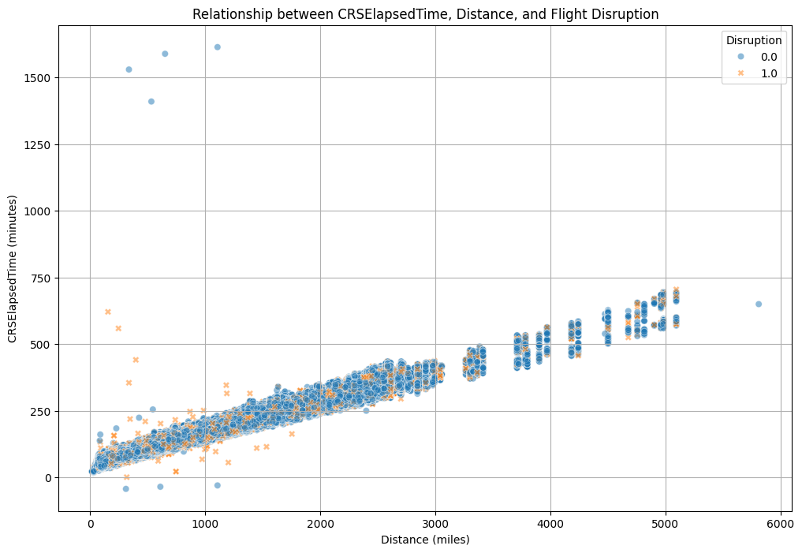

```python
# Creating Plot to show relationship between CRSElapsedTime, Distance, and Flight Disruption
# Setup the figure and axis
plt.figure(figsize=(12, 8))

# Create a scatter plot
sns.scatterplot(x='Distance', y='CRSElapsedTime', hue='Disruption', style='Disruption', data=df, alpha=0.5)

plt.title('Relationship between CRSElapsedTime, Distance, and Flight Disruption')
plt.xlabel('Distance (miles)')
plt.ylabel('CRSElapsedTime (minutes)')
plt.legend(title='Disruption')
plt.grid(True)
plt.show()
```

From the plot above we can clearly see there is an extremely strong correlation between these two features, however instead of adding both to the model, instead we have created a new enginerred feature that standerdised the data for both and then averages the value, this allows us to include infromation from both features without having to add the computational expense of computing both of them.

To summarise our finding about the categorical features that we have picked for the model, below a plot shows a similar disruption rate plot for each of the features.

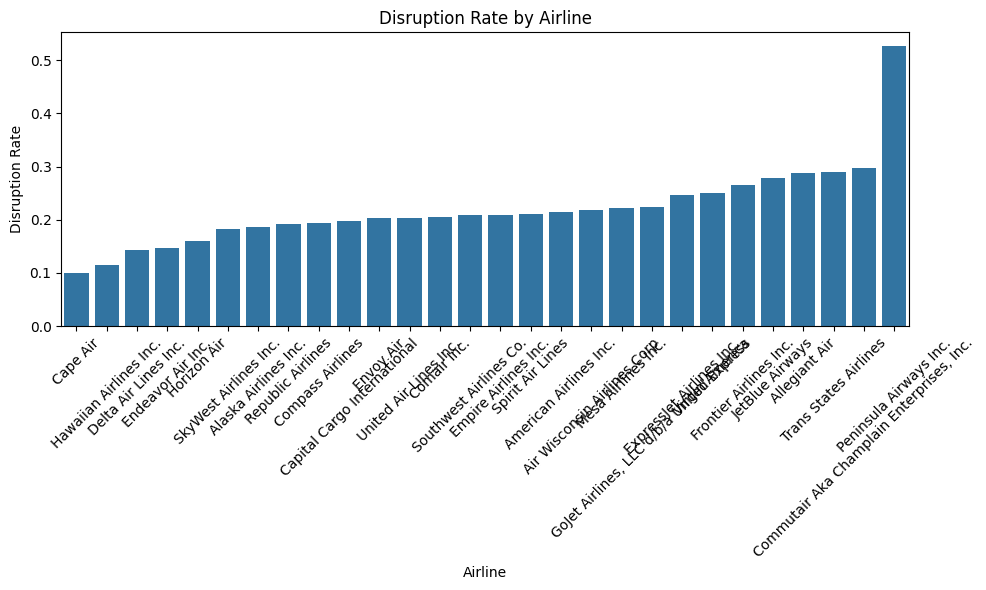

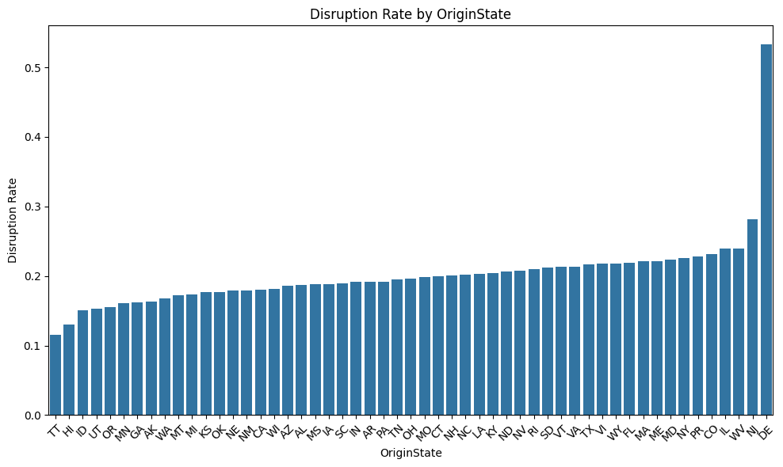

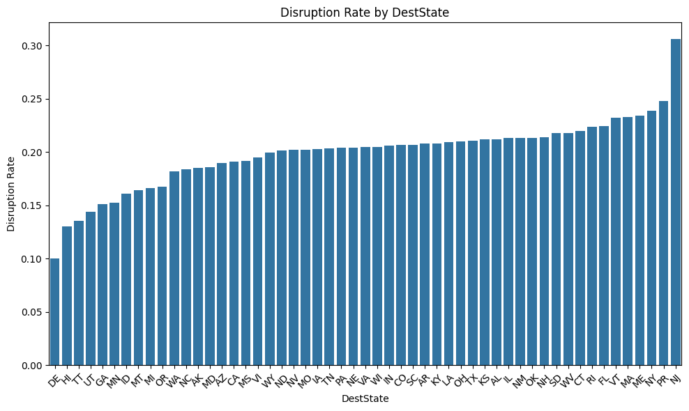

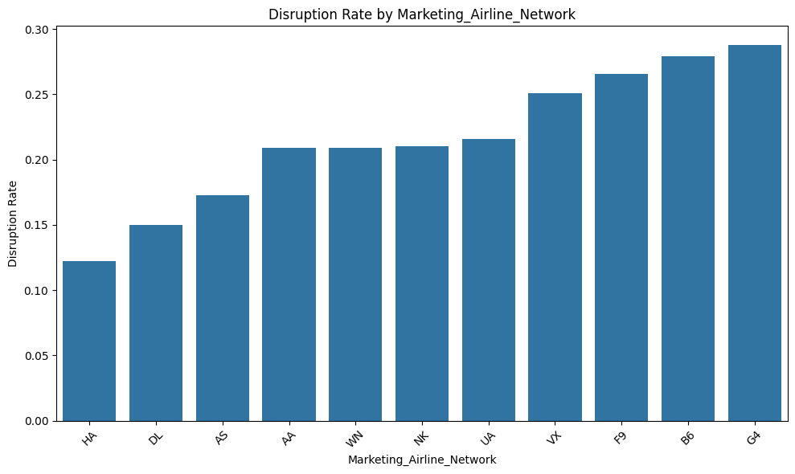

```python
#function to plot the disruption rate for a given feature with vertical bars
def plot_disruption_rate_by_feature_vertical(feature, data, top_n=None):
    plt.figure(figsize=(10, 6))
    # If top_n is specified, filter the data to include only the top_n categories by frequency
    if top_n:
        top_categories = data[feature].value_counts().nlargest(top_n).index
        filtered_data = data[data[feature].isin(top_categories)]
    else:
        filtered_data = data

    # Calculate the disruption rate
    disruption_rate = filtered_data.groupby(feature)['Disruption'].mean().reset_index().sort_values(by='Disruption', ascending=True)

    # Create the vertical bar plot
    sns.barplot(x=feature, y='Disruption', data=disruption_rate)
    plt.title(f'Disruption Rate by {feature}')
    plt.xlabel(feature)
    plt.ylabel('Disruption Rate')
    plt.xticks(rotation=45)
    plt.tight_layout()
    plt.show()

# Plotting for each feature with vertical bars
plot_disruption_rate_by_feature_vertical('Airline', df)
plot_disruption_rate_by_feature_vertical('OriginState', df)
plot_disruption_rate_by_feature_vertical('DestState', df)
plot_disruption_rate_by_feature_vertical('Marketing_Airline_Network', df)
```

As we can see from the plots above all the categorical features that we have selected do have a variation in the rate of disruption, which could help the model classify new data more accurately.

## Pre-Processing

### Features Selection

From the exploratory data analysis above the features I have decided to include in the model are:

- *CRSDepTime*
- *CRSArrTime*
- *Airline*
- *OriginState*
- *DestState*
- *Marketing_Airline_Network*
- *Pandemic*
- *FlightAverage*

The last two being the two engineered features. *Pandemic* being a binary indictor of wether the flight took place during the period Covid 19 affected disruptions significantly. *FlightAverage* being the average of *Distance* and *CRSElapsedTime* once they had been standerdised.

#### Remarks:

Used the large dataset rather than using the huge one, the reason for this was that the computation necessary for the huge one would have taken too long for it to run in a reasonable ammount of time. In addition to the there was not a major change in the results from the medium to large datasets so it is likely that this would mean that moving to the huge would not have made a significant change to my findings.

```python
num_attribs = ['CRSDepTime','CRSArrTime']
cat_attribs = ['Airline','OriginState','DestState','Marketing_Airline_Network']
```

After the Data Analysis section these were the features that were selected to be added to the models, they have been sepereted into numeric and categorical sections as each will be processed differently in the pipelines to follow.

The next few cells are the code related to the custom transformers that had to be made to add the new engineered features to the processed data.

The first relates to the binary indicator for the period during Covid 19 for the **Pandemic** feature.

```python
class PandemicIndicatorTransformer(BaseEstimator, TransformerMixin):
    def __init__(self):
        # This transformer does not need any initialization parameters
        pass

    def fit(self, X, y=None):
        # Nothing to fit, so just return self
        return self

    def transform(self, X, y=None):

        # Create a copy of X to avoid altering the original data
        X_transformed = X.copy()

        # Convert FlightDate to datetime format if it's not already
        X_transformed['FlightDate'] = pd.to_datetime(X_transformed['FlightDate'])

        # Define the start and end of the pandemic period
        pandemic_start = pd.Timestamp('2020-04-01')
        pandemic_end = pd.Timestamp('2021-04-30')

        # Create the 'Pandemic' column based on the condition
        X_transformed['Pandemic'] = ((X_transformed['FlightDate'] >= pandemic_start) &
                                     (X_transformed['FlightDate'] <= pandemic_end)).astype(int)

        # Drop the 'FlightDate' column as it should not be included in the transformed DataFrame
        X_transformed.drop(columns=['FlightDate'], inplace=True)

        return X_transformed
```

The second relates to the added feature combining the data of '*CRSElapsedTime*' and '*Distance*' into one new engineered feature, being called **FlightAverage**

```python
class AverageFlightTransformer(BaseEstimator, TransformerMixin):
    def __init__(self):
        # This transformer does not need any initialization parameters
        pass

    def fit(self, X, y=None):
        # Nothing to fit, so just return self
        return self

    def transform(self, X, y=None):
        # Ensure X is a DataFrame
        if not isinstance(X, pd.DataFrame):
            raise ValueError("Input is not a pandas DataFrame")

        # Create a copy of X to avoid altering the original data
        X_transformed = X.copy()

        # Impute missing data in 'CRSElapsedTime' with the median value
        imputer = SimpleImputer(strategy='median')
        X_transformed['CRSElapsedTime'] = imputer.fit_transform(X_transformed[['CRSElapsedTime']])

        # Standerdising the two columns before calculating their mean
        mean_ElapsedTime = np.mean(X_transformed['CRSElapsedTime'],axis=0)
        std_ElapsedTime = np.std(X_transformed['CRSElapsedTime'],axis=0)

        scaled_data_ElapsedTime = (X_transformed['CRSElapsedTime'] - mean_ElapsedTime) / std_ElapsedTime

        mean_Distance = np.mean(X_transformed['Distance'],axis=0)
        std_Distance = np.std(X_transformed['Distance'],axis=0)

        scaled_data_Distance = (X_transformed['Distance'] - mean_Distance) / std_Distance


        # Create the 'FlightAverage' column based on the condition
        X_transformed['FlightAverage'] = (scaled_data_ElapsedTime+scaled_data_Distance)/2

        # Drop the 'FlightDate' column as it should not be included in the transformed DataFrame
        X_transformed.drop(columns=['CRSElapsedTime','Distance'], inplace=True)

        return X_transformed
```

This transformer was added so that the if the data being inputed into the model contained missing values for the categorical sections it would need to have been imputed before being processed by the model. The below shows a transformer that would imput the data for this column based on the most frequent value of the column.

```python
class CategoricalImputerMostFrequent(BaseEstimator, TransformerMixin):
    def __init__(self):
        # This transformer does not need to be initialized with any parameters.
        pass

    def fit(self, X, y=None):

        X_transformed = X.copy()

        # Check if X is a DataFrame
        if not isinstance(X_transformed, pd.DataFrame):
            raise ValueError("Input is not a pandas DataFrame")

        self.most_frequent_ = X_transformed.mode().iloc[0]
        return self

    def transform(self, X, y=None):
        check_is_fitted(self, 'most_frequent_')

        X_transformed = X.copy()

        X_filled = X_transformed.fillna(self.most_frequent_)
        return X_filled
```

This cell below shows all of these pre-processing steps being put into one pipeline called '*full_pipeline*' that is able to do 4 things:

- Imput missing data for both the numeric and categorical columns
- Add the new custom engineered features to the dataset
- Standardise the numeric columns to so that they have a more bell shapped distribution
- It also converts the categories into numeric values based on the target column using target encoding. This final point was elected as when using OneHotEncoding which is the norm for categorical information the processing time far excedded a reasonable ammount of time, so this method was chosen an alternative.

### Pipeline

```python
# transformations on numerical columns
num_pipeline = Pipeline([
            ('imputer', SimpleImputer(strategy="median")),
            ('std_scaler', StandardScaler()),
        ])

# Transformation for Categorical columns
categorical_transformer = Pipeline(steps=[
    ('imputer', CategoricalImputerMostFrequent()),
    ('target_encoder', TargetEncoder())
])

# Pandemic Transformer
pandemic_transformer = Pipeline(steps=[
    ('covid_indicator', PandemicIndicatorTransformer()),
])

# FlightAverage Transformer
average_transformer = Pipeline(steps=[
    ('average_length', AverageFlightTransformer()),
])

# Full pipeline containing all the pre-processing steps necessary
full_pipeline = ColumnTransformer([
                ("num", num_pipeline, num_attribs),
                ('average',average_transformer,['CRSElapsedTime','Distance']),
                ("covid", pandemic_transformer, ['FlightDate']),
                ('cat_impute', categorical_transformer , cat_attribs)
         ])
```

#### Processing training and valadation data

**Notation**:

- *X*: Training set attributes
- *y*: Training set labels
- *XX*: Valadation set attributes
- *yy*: Valadation set labels

```python
y = train_data["Disruption"].copy().astype(int) # training labels
X = full_pipeline.fit_transform(train_data.copy(),y)


yy = val_data['Disruption'].copy().astype(int)
XX = full_pipeline.transform(val_data.copy())
# NOT using 'fit_transform' for 'XX' so that parameters are based on the training set
```

```python
pd.DataFrame(X).head()
```

|  | 0 | 1 | 2 | 3 | 4 | 5 | 6 | 7 |
| --- | --- | --- | --- | --- | --- | --- | --- | --- |
| 0 | 0.775664 | 0.633011 | -0.144353 | 0.0 | 0.209248 | 0.218560 | 0.203271 | 0.209248 |
| 1 | 0.983044 | 1.666403 | 1.299585 | 0.0 | 0.203631 | 0.231619 | 0.219645 | 0.215584 |
| 2 | 0.578652 | 0.857833 | 1.523917 | 0.0 | 0.214349 | 0.220693 | 0.210752 | 0.208738 |
| 3 | -0.250870 | 0.315499 | 1.150699 | 0.0 | 0.221959 | 0.216532 | 0.238672 | 0.215584 |
| 4 | 0.848247 | 0.820362 | -0.602873 | 0.0 | 0.209248 | 0.195586 | 0.212970 | 0.209248 |

Just a quick look at the top 5 entries of the processed df to make sure all transformations correctly applied and it appears they have been.

## Model Selection

### Plotting ROC curve for Decision Tree, Random Forest and SGD Classifier

The **ROC curve** (Receiver Operating Characteristic curve), has been used to evalutae the performance of the binary classification models across different thresholds.

The ROC curve plots TPR vs FPR:

- **True Positive Rate (TPR)**, also known as sensitivity or recall, on the y-axis. It is defined as (TP / (TP + FN)), where (TP) is the number of true positives and (FN) is the number of false negatives. The TPR measures the proportion of actual positives correctly identified.
- **False Positive Rate (FPR)**, on the x-axis. It is calculated as (FP / (FP + TN)), where (FP) is the number of false positives and (TN) is the number of true negatives. The FPR measures the proportion of actual negatives that are incorrectly classified as positives.

The ROC curve demonstrates the trade-off between sensitivity and specificity (1 - FPR) at various thresholds. A perfect classifier's ROC curve would reach the top left corner of the plot, indicating a TPR of 1 and an FPR of 0. As seen from the models below none of the models do an amazing job at reaching this corner however the graph still provided useful insight into which model is working better.

The AUC summarizes the entire ROC curve in a single value, representing the likelihood that a classifier will rank a randomly chosen positive instance higher than a randomly chosen negative one. Values range from 0 to 1, with 0.5 indicating no discriminative ability and 1.0 indicating perfect discrimination.

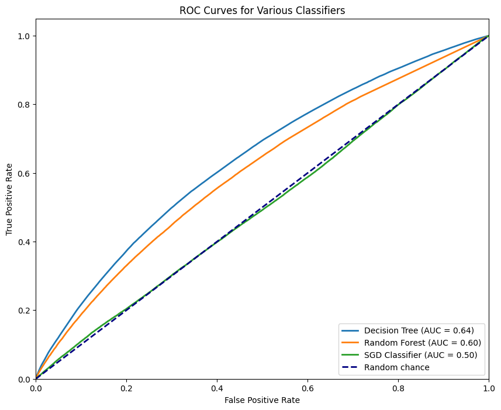

```python
# Initialize the classifiers
classifiers = {
    # Some parameters had to be applied to each classifier otherwise the computation time took too long
    "Decision Tree": DecisionTreeClassifier(max_depth=10,random_state=42),
    "Random Forest": RandomForestClassifier(n_estimators=20,random_state=42,n_jobs=-1),
    "SGD Classifier": SGDClassifier(loss="hinge",max_iter=1000, tol=1e-3,random_state=42)
}

warnings.filterwarnings("ignore", category=ConvergenceWarning)

# Plot ROC curves
plt.figure(figsize=(10, 8))
for name, classifier in classifiers.items():
    # Train the classifier on the training set (X, y)
    classifier.fit(X, y)

    # Predict probabilities for the positive class on the test set (XX, yy)
    if hasattr(classifier, "predict_proba"):
        y_score = classifier.predict_proba(XX)[:, 1]
    else:  # Use decision function for SGDClassifier
        y_score = classifier.decision_function(XX)

    # Compute ROC curve and AUC for the test set
    fpr, tpr, _ = roc_curve(yy, y_score)
    roc_auc = auc(fpr, tpr)

    # Plot
    plt.plot(fpr, tpr, lw=2, label=f'{name} (AUC = {roc_auc:.2f})')

plt.plot([0, 1], [0, 1], color='navy', lw=2, linestyle='--', label='Random chance')
plt.xlim([0.0, 1.0])
plt.ylim([0.0, 1.05])
plt.xlabel('False Positive Rate')
plt.ylabel('True Positive Rate')
plt.title('ROC Curves for Various Classifiers')
plt.legend(loc="lower right")
plt.show()
```

As we can see from the plot tje Decision Tree and Random Forest models did relatively similar with their **AUC** score, both beating the SGD Classifier. To investigate which model to select, additional information has been provided below. For each models I have plotted the Confusion Matrix, the recall, the precision and the F1 score. This was done to provide a better insight what the model is actually doing to help make an informed decision on which model to select.

```
Decision Tree:
Precision: 0.49
Recall: 0.01
F1 Score: 0.03

Random Forest:
Precision: 0.31
Recall: 0.20
F1 Score: 0.25

SGD Classifier:
Precision: 0.00
Recall: 0.00
F1 Score: 0.00
```

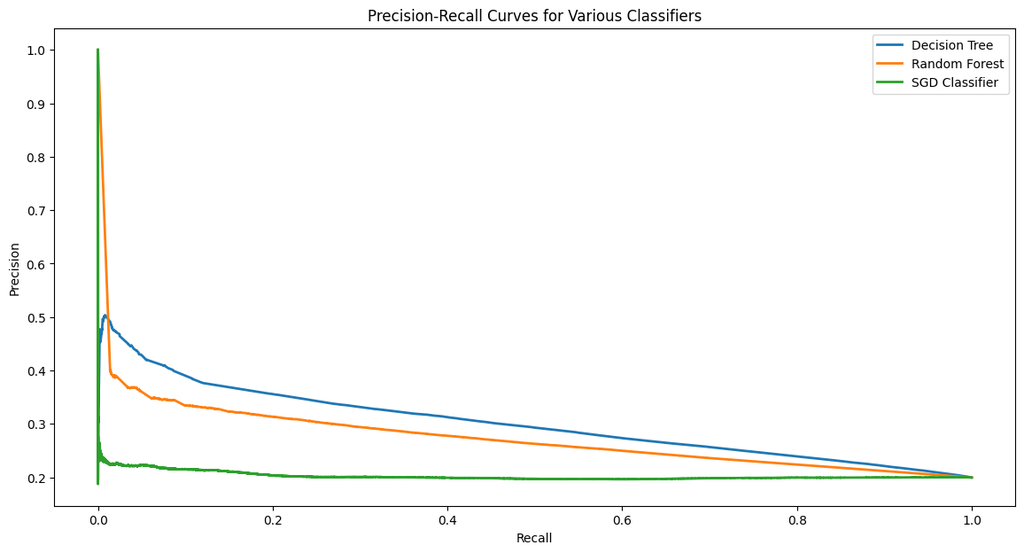

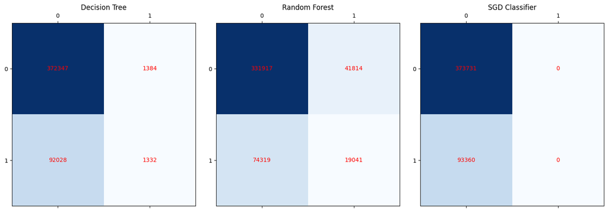

```python
# Initialize the classifiers with parameters adjusted for faster computation
classifiers = {
    "Decision Tree": DecisionTreeClassifier(max_depth=10,random_state=42),
    "Random Forest": RandomForestClassifier(n_estimators=10,random_state=42, n_jobs=-1),
    "SGD Classifier": SGDClassifier(loss="hinge", max_iter=1000, tol=1e-3,random_state=42)
}

# Set up plotting for Precision-Recall curves
plt.figure(figsize=(14, 7))
for name, classifier in classifiers.items():
    # Train the classifier
    classifier.fit(X, y)

    # Predict probabilities if available, else use decision function
    if hasattr(classifier, "predict_proba"):
        y_scores = classifier.predict_proba(XX)[:, 1]
    else:  # Use decision function
        y_scores = classifier.decision_function(XX)

    # Compute Precision-Recall curve
    precision, recall, _ = precision_recall_curve(yy, y_scores)

    # Compute and print precision, recall, and F1 score
    y_pred = classifier.predict(XX)
    print(f"{name}:")
    print(f"Precision: {precision_score(yy, y_pred, zero_division=0):.2f}")
    print(f"Recall: {recall_score(yy, y_pred, zero_division=0):.2f}")
    print(f"F1 Score: {f1_score(yy, y_pred, zero_division=0):.2f}\n")

    # Plot Precision-Recall curve
    plt.plot(recall, precision, lw=2, label=f'{name}')

plt.xlabel('Recall')
plt.ylabel('Precision')
plt.title('Precision-Recall Curves for Various Classifiers')
plt.legend(loc="best")
plt.show()

# Display confusion matrices
fig, axes = plt.subplots(nrows=1, ncols=3, figsize=(15, 5))
for ax, (name, classifier) in zip(axes.flatten(), classifiers.items()):
    disp = confusion_matrix(yy, classifier.predict(XX))
    ax.matshow(disp, cmap='Blues')
    ax.title.set_text(name)
    for (i, j), val in np.ndenumerate(disp):
        ax.text(j, i, f'{val}', ha='center', va='center', color='red')
plt.tight_layout()
plt.show();
```

Above the Precision vs Recall graph has been shown to compare the three models

- **Precision** (Positive Predictive Value): The proportion of positive identifications that were actually correct.
- **Recall** (Sensitivity or True Positive Rate): The proportion of actual positives correctly identified.

The Precision-Recall curve plots precision against recall for different threshold values, highlighting the trade-off between the two metrics. A high area under this curve indicates a model that achieves both high precision and high recall. With a perfect model the graph with reach the top right, clearly again this is not the case for our models, but again provided useful insight into how each models performs.

Secondly, for each model the F1 score and associated Precision, Recall values have been printed to help decide between the models.

**Remark**: Another metric that could have been used to determine which model was selected was the **AUC of Precision-Recall Curve** (Area Under Curve) the reason this was not used as the scoring metric is as one can see from the graph above none of the 3 classifiers presented normal behaviour for this graph which would usually be a curve near the top right. So a decision was made to not use this metric since it was considered not applicable in this situation.

## Fine Tuning

### Grid Search - Hyperparameter tuning

```python
# Define the model
rf = RandomForestClassifier(random_state=42,n_jobs=-1)

# Define the parameter grid to search over
# A larger variety of grid search parameters would have been prefered but due to computational costs this was not possible.
param_grid = {
    'n_estimators': [10, 20, 30], # Number of trees in the forest
    'max_depth': [10, 15]     # Maximum depth of the tree
}

# Define the scoring function
scoring = make_scorer(roc_auc_score)

# Initialize the GridSearchCV object
grid_search = GridSearchCV(estimator=rf, param_grid=param_grid, scoring='roc_auc', cv=3, n_jobs=-1, verbose=0)

# Fit the model
grid_search.fit(X, y)

# Get the best parameters and the best score
best_parameters = grid_search.best_params_
best_score = grid_search.best_score_
```

Having completed this grid search, below I have outlined which combination of parameters ended up being the best combination. As we can see the combination of *n_estimators* = 30 and *max_depth* = 15 was selected however both of these lie at end of their respective choice meaning that bettter values for the parameters may lie outside our designated search grid. Ideally we would add more parameters to our grid search to ensure that these parameters are the optimal combination rather than the best that was possible with the given inputs. This was not done however since it would have greatly increased computation gain and after outputting the **AUC** for each combination there are minimal gains to be made irrelevent of the combination being selected, so the cost vs reward here would not be in favour of adding new grid search parameters.

```python
grid_search_results = grid_search.cv_results_
for mean_score, params in zip(grid_search_results["mean_test_score"], grid_search_results["params"]):
    print(np.round(mean_score,7), params)

print("Best Parameters:", best_parameters)
print("Best AUC Score:", best_score)

# Setting our model to the best of those we tried
final_model = grid_search.best_estimator_
```

```
0.642162 {'max_depth': 10, 'n_estimators': 10}
0.6427468 {'max_depth': 10, 'n_estimators': 20}
0.6430542 {'max_depth': 10, 'n_estimators': 30}
0.6440587 {'max_depth': 15, 'n_estimators': 10}
0.6466898 {'max_depth': 15, 'n_estimators': 20}
0.6477559 {'max_depth': 15, 'n_estimators': 30}
Best Parameters: {'max_depth': 15, 'n_estimators': 30}
Best AUC Score: 0.6477558832075626
```

## Test Set Evaluation

```python
# Processing the Test Set before it is used by the model
y_test = combined_df_test["Disruption"].copy().astype(int)
X_test = full_pipeline.transform(combined_df_test.copy())
# NOT using 'fit_transform' for 'X_test' so that parameters are based on the training set


y_pred_proba = final_model.predict_proba(X_test)[:, 1]
# Calculating the probabilities on the final model on the Test Data

# Calculate AUC
auc = roc_auc_score(y_test, y_pred_proba)
print(f'AUC for the Test Data: {auc}')
```

```
AUC for the Test Data: 0.6488709155885555
```

This **AUC** score is not great, but it is good enough for the purposes of this practical. It could certainly be improved by including more features but this would have increased computational cost, but it doesn't seem unreasonable given the values we were getting on the valadation set.

## Result Analysis

Calculating a 95% confidence interval for the test set AUC, as the single AUC value above doesn't give an indication of how much variance there was in this value. This was done by creating a non-parametric bootstrap, using resampling with replacement.

```python
# Function to perform bootstrapping and calculate AUC confidence interval
def bootstrap_auc_ci(y_true, y_scores, n_bootstraps=1000, alpha=0.95):
    rng = np.random.RandomState(seed=42)  # Seed for reproducibility
    bootstrapped_aucs = []

    y_true = np.array(y_true)
    y_scores = np.array(y_scores)

    for _ in range(n_bootstraps):
        # Randomly generate indices for the bootstrap sample
        indices = rng.randint(0, len(y_true), len(y_true))
        # Use the randomly generated indices to create the bootstrap sample
        y_true_sample = y_true[indices]
        y_scores_sample = y_scores[indices]
        # Calculate the AUC for the bootstrap sample
        if len(np.unique(y_true_sample)) > 1:  # Check if the sample contains more than one class
            auc_score = roc_auc_score(y_true_sample, y_scores_sample)
            bootstrapped_aucs.append(auc_score)

    # Calculate the confidence interval bounds
    lower_bound = np.percentile(bootstrapped_aucs, 100 * ((1 - alpha) / 2))
    upper_bound = np.percentile(bootstrapped_aucs, 100 * (alpha + (1 - alpha) / 2))

    return lower_bound, upper_bound


# Calculate AUC
auc = roc_auc_score(y_test, y_pred_proba)
print(f"AUC: {auc}")

# Estimate the confidence interval for the AUC
alpha = 0.95  # 95% confidence interval
lower, upper = bootstrap_auc_ci(y_test, y_pred_proba, n_bootstraps=500, alpha=alpha)
print(f"{alpha*100}% Confidence interval for the AUC: [{lower:.3f}, {upper:.3f}]")
```

```
AUC: 0.6488709155885555
95.0% Confidence interval for the AUC: [0.647, 0.651]
```

A final piece of analysis of the final model was conducted, to find out which features that were put into the model were the most significant.

```python
feature_importances = final_model.feature_importances_
features = ['CRSDepTime','CRSArrTime','FlightAverage','Pandemic','Airline','OriginState','DestState','Marketing_Airline_Network']
sorted(zip(feature_importances,features),reverse=True)
```

```
[(0.2313241455789911, 'CRSDepTime'),
 (0.22849361083475964, 'CRSArrTime'),
 (0.13235526968324332, 'FlightAverage'),
 (0.08854143821686195, 'Airline'),
 (0.08802207825036783, 'Pandemic'),
 (0.08592787764768535, 'OriginState'),
 (0.08566010311918758, 'DestState'),
 (0.05967547666890311, 'Marketing_Airline_Network')]
```

From this we can see that *CRSDepTime* is the most important feature, followed up by *CRSArrTime* and then *FlightAverage* our engineered feature of the average of distance and time elapsed. Interestingly the importance of the airline was roughly the same as wether the flight took place during Covid 19 disrupted period.